# Assignment description

# Structure of air quality (and many types of environmental) data

Air pollution data (observations or model predictions) consist of realizations of multiple variables in time and space. How can we structure this data so that we may efficiently apply simple statistical analyses on them? In general, the goal of statistical analysis can be thought of as having two products:

- statistical description (providing a few metrics which represent a large quantity of values)
- statistical inference (which includes hypothesis testing to infer properties of a population, and predictions resulting from inferred characteristics of variables or relationships among them)

In this project, we will learn methods of exploratory data analysis using relational models of data. We will cover the software package R.

# Assignment description

[figure not shown]

The assignment is to analyze measurements from the Swiss Federal Office of the Environment (BAFU/OFFEV/FOEN) network. The objective is to observe seasonal and diurnal patterns in concentrations of each pollutant, and understand the interplay of emissions, photochemistry, and meteorology that gives rise to these patterns to the extent that they can be inferred. You can find many details on the [BAFU website](http://www.bafu.admin.ch/luft/index.html?lang=en), and in the lectures of the course.

See course handout for exact assignment instructions.

# Data analysis

*Data analysis* describes the process of reducing a set of data to a few relevant conclusions.

*Code* describes data (e.g., measurements) and its transformations (e.g., averaging).

- Data are stored as variables (nouns)
- Transformations are described through functions (verbs)

Structuring your data appropriately can significantly reduce the number of steps required for many types of transformations.

## Examples of data models

Data models describe entities and their relationships to other entities.

- Graph (Hierarchical, Network)
- Relational
- “Multidimensional” cube model

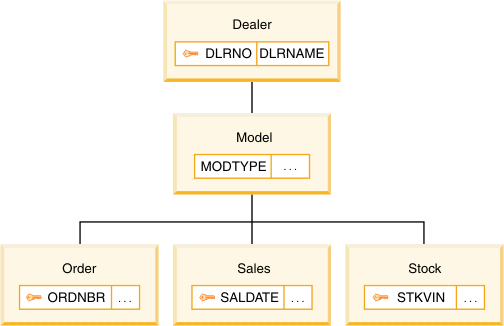

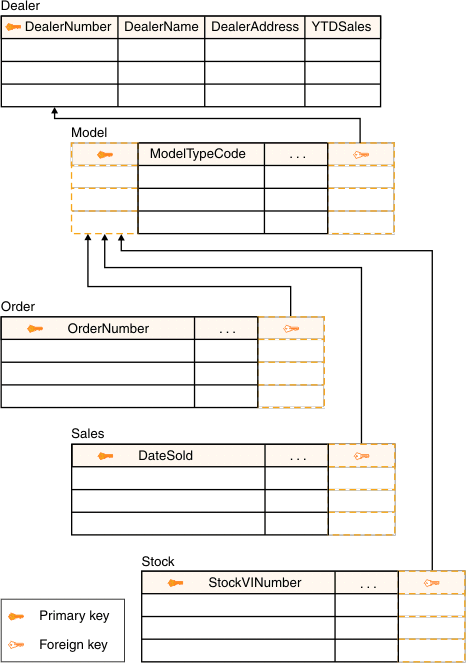

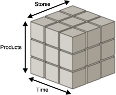

These models can be implemented by databases in data warehouses, or data structures residing in local memory.

Array representation in R:

```r
dimnames(arr)
```

```
## $year
## [1] "2012" "2013" "2014"
##
## $month
##  [1] "Jan" "Feb" "Mar" "Apr" "May" "Jun" "Jul" "Aug" "Sep" "Oct" "Nov" "Dec"
##
## $day
##  [1] "1"  "2"  "3"  "4"  "5"  "6"  "7"  "8"  "9"  "10" "11" "12" "13" "14" "15"
## [16] "16" "17" "18" "19" "20" "21" "22" "23" "24" "25" "26" "27" "28" "29" "30"
## [31] "31"
##
## $hour
##  [1] "0"  "1"  "2"  "3"  "4"  "5"  "6"  "7"  "8"  "9"  "10" "11" "12" "13" "14"
## [16] "15" "16" "17" "18" "19" "20" "21" "22" "23"
##
## $variable
## [1] "O3"   "NO2"  "CO"   "PM10" "TEMP" "PREC" "RAD"
```

```r
arr["2013","Jul","20",,"O3"]
```

```
##     0     1     2     3     4     5     6     7     8     9    10    11    12
##  78.4  71.8  69.5  76.8  63.3  50.3  45.2  54.9  65.2  56.6  61.5  74.1  82.4
##    13    14    15    16    17    18    19    20    21    22    23
##  91.9  98.8 110.4 118.3 122.0 122.9 113.2  99.9  85.8  54.9  48.9
```

Some operations can be efficiently performed with arrays:

```r
apply(arr["2013",,,,],MARGIN=c("month","variable"), FUN=mean, na.rm=TRUE)
```

```
##      variable
## month       O3      NO2        CO     PM10       TEMP       PREC       RAD
##   Jan 22.64865 47.52375 0.4440108 22.54845  2.2271505 0.08721400  46.31774
##   Feb 40.58125 45.05580 0.4380952 28.74501  0.6016369 0.07113095  85.00015
##   Mar 35.02078 50.33841 0.4849328 35.95249  4.7498656 0.10713324  98.91492
##   Apr 50.78187 40.48799 0.3930556 25.55132 10.6093056 0.11930556 170.54847
##   May 51.85189 38.63450 0.3339166 12.29838 11.9751344 0.18561828 174.21317
##   Jun 59.61657 38.92350 0.3386111 17.55225 17.6750000 0.12517385 248.54292
##   Jul 76.19515 38.44542 0.3680108 19.92781 22.3884409 0.16424731 272.65753
##   Aug 66.49771 34.13576 0.3336022 17.26532 20.9435484 0.05397039 241.67258
##   Sep 43.20181 42.02855 0.3945833 17.52681 17.0044444 0.12472222 157.18375
##   Oct 24.74307 40.52557 0.4131720 17.46508 13.7291667 0.28721400  82.58642
##   Nov 25.85577 36.38623 0.3695833 13.65309  6.0034722 0.15724234  53.88542
##   Dec 18.55666 57.09166 0.5268817 26.03401  3.8581989 0.13575269  46.13616
```

Hierarchical representation:

```r
tree[["2013"]][["Jul"]][["20"]][c("11","12")]
```

```
## $`11`
## $`11`$O3
## [1] 74.1
##
## $`11`$NO2
## [1] 31.6
##
## $`11`$CO
## [1] 0.4
##
## $`11`$PM10
## [1] 15
##
## $`11`$TEMP
## [1] 20.8
##
## $`11`$PREC
## [1] 0
##
## $`11`$RAD
## [1] 799.3
##
##
## $`12`
## $`12`$O3
## [1] 82.4
##
## $`12`$NO2
## [1] 35.1
##
## $`12`$CO
## [1] 0.4
##
## $`12`$PM10
## [1] 17.4
##
## $`12`$TEMP
## [1] 21.7
##
## $`12`$PREC
## [1] 0
##
## $`12`$RAD
## [1] 880.3
```

## Data tables

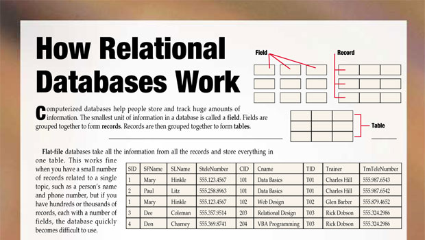

Relations with 2-D structure (“a multiset of tuples”).

- Observations along rows (identified by unique “keys”)
- Variables along columns

Like matrices, but different:

- Can be a collection of heterogeneous data types along columns: float, integer, string, Boolean, etc.
- The set of operations defined for tables contain ones which are different from matrices. For instance:
  - matrices: scalar, matrix, Hadamard, and Kronecker products; transpose, determinant, decomposition (e.g., SVD), “slice” (equivalent of subset/select for tables)
  - tables: join, group, subset (observations), select (variables)

## Example

Import example data:

View in “wide” format:

```r
kable(data[1:2,])
```

| datetime | O3 | NO2 | CO | PM10 | TEMP | PREC | RAD |
| --- | --- | --- | --- | --- | --- | --- | --- |
| 31.12.2012 01:00 | 7.8 | 56.3 | 0.5 | 16.1 | 3.8 | 0 | -2.4 |
| 31.12.2012 02:00 | 22.4 | 38.0 | 0.4 | 11.6 | 4.1 | 0 | -2.3 |

Convert to “long” format:

```r
library(reshape2) # makes melt() library available
kable(melt(data[1:2,], id.vars="datetime"))
```

| datetime | variable | value |
| --- | --- | --- |
| 31.12.2012 01:00 | O3 | 7.8 |
| 31.12.2012 02:00 | O3 | 22.4 |
| 31.12.2012 01:00 | NO2 | 56.3 |
| 31.12.2012 02:00 | NO2 | 38.0 |
| 31.12.2012 01:00 | CO | 0.5 |
| 31.12.2012 02:00 | CO | 0.4 |
| 31.12.2012 01:00 | PM10 | 16.1 |
| 31.12.2012 02:00 | PM10 | 11.6 |
| 31.12.2012 01:00 | TEMP | 3.8 |
| 31.12.2012 02:00 | TEMP | 4.1 |
| 31.12.2012 01:00 | PREC | 0.0 |
| 31.12.2012 02:00 | PREC | 0.0 |
| 31.12.2012 01:00 | RAD | -2.4 |
| 31.12.2012 02:00 | RAD | -2.3 |

The transformation from the wide format to long format as shown above (and vice versa) is known as “pivoting”. Other common operations with data tables include:

- extracting columns and rows
- joining (merging) two tables

## Split-apply-combine (SAC) strategy

Data tables permit a set of operations common to many types of data analyses.

[figure not shown]

General strategy:

1. *split* table row-wise by a categorical variable (X)
2. *apply* function (Y) on selected variable
3. *combine* results into another table

Example (as shown in Lesson 1):

1. *split* table row-wise by month
2. *apply* mean on selected variable
3. *combine* summary statistics (i.e., mean) into a table

The basic syntax for SAC and describing a graphic in R can be similar in structure.

To return a data table after grouping rows of another data table by `variable1` and `variable2`; applying `cor` to each piece, and recombining:

```r
library(dplyr)
data_table %>%                      # data table
  group_by(variable1, variable2) %>% # grouping variables
  summarize(correlation=cor(x, y))   # (aggregating) function
```

There are *many* variations on this specification, but this is the general idea for creating a graphic:

```r
library(ggplot2)
ggplot(data=data_table) +             # data table
  facet_grid(variable1~variable2) +   # grouping variables
  geom_line(mapping=aes(x, y, color=z)) # aesthetics
```

The last example shows the application of a popular programming concept for graph specification. We will show more such examples in the following lessons.

*Note that `dplyr` and `ggplot2` packages can now be loaded together through the `tidyverse` package. For data table pivoting, there are many options, including `melt`/`dcast` from the `reshape2` package shown above. We will use `gather`/`spread` from the `tidyr` package (which can is also loaded through `tidyverse`.*